# 第2章 基本数据类型

武汉大学经济与管理学院  
刘开军 博士  
Email: kjliu@whu.edu.cn

## 标识符(identifier)

R中的标识符（包括变量名、函数名等）只能由**英文字母、数字0~9、下划线、句点**组成，并且第1个字符必须是英文字母。

| 标识符 | 是否合法 |
| --- | --- |
| `a` | 合法，但不建议。应尽量使用有意义的名称 |
| `a1` | 合法，但不建议。应尽量使用有意义的名称 |
| `myname` | 合法 |
| `old_data` | 合法 |
| `new.data` | 合法 |
| `get_equation_root` | 合法 |
| `1a` | 不合法，起始字符必须是英文字母 |
| `_var` | 不合法，起始字符必须是英文字母 |

建议：标识符的名称只使用有意义的英文单词，用下划线或句点将单词连接起来。

特别注意：

R区分大小写  
R区分大小写  
R区分大小写

所以，`myname`与`MyName`是两个不同的标识符。

另外，不要使用R已经使用过的标识符。例如，不要使用`sqrt`为自己编写的函数命名。

## 基本数据类型

R可以处理的数据类型（模式, mode）包括：

- 数值型(numeric)，例如：10、1.5等；
- 字符型(character)，用单引号或双引号括起来的文本，例如：`"Hello"`、`'Good moring'`等；
- 逻辑型(logical)，只能取TRUE或FALSE；
- 复数型(complex)，例如：2+3i等；
- 原生型(raw)，即二进制数据。

要查看某个变量的数据类型，可调用函数`mode()`。例如：

```r
a<-10; b<-'Hello world'; c<-TRUE; d<-2+3i
mode(a); mode(b); mode(c); mode(d)
```

```
## [1] "numeric"
```

```
## [1] "character"
```

```
## [1] "logical"
```

```
## [1] "complex"
```

可以用分号将多个语句连接起来放在一行，分号是语句的结束符。

逻辑型数据只有TRUE和FALSE两种值，TRUE可简写为T，FALSE可简写为F。例如：

```r
a <- T   #等价于 a <- TRUE
mode(a)
```

```
## [1] "logical"
```

逻辑型数据也可以参与数值计算，此时TRUE会被当作1，FALSE会被当作0。例如：

```r
a <- c(TRUE, FALSE, TRUE, TRUE)
sum(a)   #求和
```

```
## [1] 3
```

```r
mean(a)    #求平均值
```

```
## [1] 0.75
```

**特殊的常数值**

以下几个特殊的常数值是被经常使用的：

- Inf，表示Infinite，表示无穷大，是一个数值型常数；用函数is.infinite(x)来判断变量x是否是无穷大(Inf或-Inf)，用函数is.finite(x)来判断变量x是否为有限值；
- NaN，表示Not A Number，是一个特殊的数值型常数；在数值计算中，如果计算结果不能用一个数值表示，那么将结果记为NaN；用函数is.nan(x)来判断变量x是否是NaN值；
- NULL，表示空值，是指一个空指针(C/C++)；用函数is.null(x)来判断变量x是否是空值；
- NA，表示Not Available，是指缺失值；用函数is.na(x)来判断变量x是否是缺失值；

以上值都是常数，不需要用引号括起来。例如：

```r
a <- c(1, 3, Inf)
is.finite(a)
## [1]  TRUE  TRUE FALSE

a <- 2/0
a
## [1] Inf
is.infinite(a)
## [1] TRUE

b <- (1/0 + 1/0)
b
## [1] Inf
is.infinite(b)
## [1] TRUE

c <- (1/0 - 1/0)
c
## [1] NaN
is.infinite(c); is.nan(c)
## [1] FALSE
## [1] TRUE

d <- NaN
e <- d + Inf
e
## [1] NaN
is.infinite(e); is.nan(e)
## [1] FALSE
## [1] TRUE

NaN==NaN  #判断两个NaN是否相等
## [1] NA

NaN^0  #计算NaN的0次方
## [1] 1

NA==NA  #判断两个NA是否相等
## [1] NA

NA^0    #计算NA的0次方
## [1] 1

f <- c(10, Inf, NULL, NaN, NA)
is.nan(f)  #只有NaN被判断为TRUE，NA被判断为FALSE
## [1] FALSE FALSE  TRUE FALSE

is.na(f)   #注意：NaN和NA都会被判断为TRUE
## [1] FALSE FALSE  TRUE  TRUE
```

## 组合数据

R处理数据时通常要把基本数据类型组合成一定的结构，包括：向量(vector)、矩阵(matrix)、数组(array)、数据框(data.frame)和列表(list)。

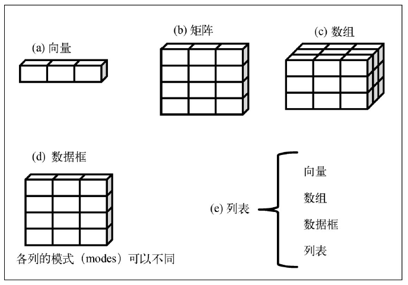

## 向量(vector)

向量(vector)是用于存储数值型、字符型、逻辑型数据的一维数组。用函数`c()`将若干个数据组合成一个向量。一个向量中的元素必须是同一种数据类型。

```r
age <- c(1, 3, 5, 2, 11, 9, 3, 9)
workmates <- c("Zhang", "Chen", "Liu")
a <- c(TRUE, TRUE, FALSE, FALSE)
b <- c(10, "Hello")   # error
```

**标量**是只含有一个元素的特殊向量。创建标量可以使用函数`c()`，也可以不使用函数`c()`，直接赋值。

```r
a <- c(10)
b <- 10       # also OK
```

我们可以通过**下标**来访问向量的元素，应将下标放在**方括号**中。第1个元素的下标是1，第2个元素的下标是2，依次类推。

```r
age <- c(1, 3, 5, 2, 11, 9, 3, 9)
age[2]
```

```
## [1] 3
```

```r
workmates <- c("Zhang", "Chen", "Liu")
workmates[1]
```

```
## [1] "Zhang"
```

**冒号操作符**

用冒号操作符连接两个整数，可以生成一个步进数列。例如，2:6等价于2,3,4,5,6，6:2等价于6,5,4,3,2。可以用冒号操作符来创建向量。

```r
mydata <- c(11:15)
mydata
```

```
## [1] 11 12 13 14 15
```

```r
mydata <- 11:15
mydata
```

```
## [1] 11 12 13 14 15
```

```r
mydata[1]+mydata[2]+mydata[3]+mydata[4]+mydata[5]
```

```
## [1] 65
```

如果要同时访问向量的多个元素，可以在方括号中用一个向量作为下标。例如：

```r
workmates <- c("Zhang", "Chen", "Liu", "Wang", "Li", "Feng")
workmates[c(3, 1, 5)]   #选出指定的元素
```

```
## [1] "Liu"   "Zhang" "Li"
```

```r
workmates[2:5]
```

```
## [1] "Chen" "Liu"  "Wang" "Li"
```

```r
workmates[6:1]   #反转workmates
```

```
## [1] "Feng"  "Li"    "Wang"  "Liu"   "Chen"  "Zhang"
```

## 矩阵(matrix)

矩阵(matrix)是一个二维数组。组成矩阵的元素也必须是同一种数据类型。

用函数`matrix()`创建矩阵，语法为：

mymatrix <- matrix(vector, nrow=num1, ncol=num2)

例如：

```r
mydata <- matrix(1:20, nrow=4)
mydata
```

```
##      [,1] [,2] [,3] [,4] [,5]
## [1,]    1    5    9   13   17
## [2,]    2    6   10   14   18
## [3,]    3    7   11   15   19
## [4,]    4    8   12   16   20
```

```r
mydata <- matrix(1:20, ncol=4)
mydata
```

```
##      [,1] [,2] [,3] [,4]
## [1,]    1    6   11   16
## [2,]    2    7   12   17
## [3,]    3    8   13   18
## [4,]    4    9   14   19
## [5,]    5   10   15   20
```

```r
mydata <- matrix(1:20, nrow=4, ncol=3)
mydata
```

```
##      [,1] [,2] [,3]
## [1,]    1    5    9
## [2,]    2    6   10
## [3,]    3    7   11
## [4,]    4    8   12
```

```r
mydata <- matrix(1:13, nrow=4, ncol=5)
mydata
```

```
##      [,1] [,2] [,3] [,4] [,5]
## [1,]    1    5    9   13    4
## [2,]    2    6   10    1    5
## [3,]    3    7   11    2    6
## [4,]    4    8   12    3    7
```

可见，`matrix()`是按列来填充矩阵。

**访问矩阵中元素的方法**

| 表达式 | 功能 |
| --- | --- |
| `mymatrix[i, j]` | 矩阵第i行第j列的元素 |
| `mymatrix[i, ]` | 矩阵的第i行元素 |
| `mymatrix[, j]` | 矩阵的第j列元素 |

其中，行（或列）的下标可以是一个数值，也可以是一个向量。例如：

```r
mydata <- matrix(1:20, nrow=4)
mydata
```

```
##      [,1] [,2] [,3] [,4] [,5]
## [1,]    1    5    9   13   17
## [2,]    2    6   10   14   18
## [3,]    3    7   11   15   19
## [4,]    4    8   12   16   20
```

```r
mydata[2, 3]
```

```
## [1] 10
```

```r
mydata[1,]
```

```
## [1]  1  5  9 13 17
```

```r
mydata[2:3, 2:4]
```

```
##      [,1] [,2] [,3]
## [1,]    6   10   14
## [2,]    7   11   15
```

```r
mydata[, 5:1]
```

```
##      [,1] [,2] [,3] [,4] [,5]
## [1,]   17   13    9    5    1
## [2,]   18   14   10    6    2
## [3,]   19   15   11    7    3
## [4,]   20   16   12    8    4
```

```r
mydata[c(1,3), 5:1]
```

```
##      [,1] [,2] [,3] [,4] [,5]
## [1,]   17   13    9    5    1
## [2,]   19   15   11    7    3
```

## 数组(array)

myarray <- array(vector, dimensions)

例如：

```r
mydata <- array(1:24, c(2, 3, 4))
mydata
```

```
## , , 1
##
##      [,1] [,2] [,3]
## [1,]    1    3    5
## [2,]    2    4    6
##
## , , 2
##
##      [,1] [,2] [,3]
## [1,]    7    9   11
## [2,]    8   10   12
##
## , , 3
##
##      [,1] [,2] [,3]
## [1,]   13   15   17
## [2,]   14   16   18
##
## , , 4
##
##      [,1] [,2] [,3]
## [1,]   19   21   23
## [2,]   20   22   24
```

通过下标来访问数组中的元素。

```r
mydata[1, 1, 1]
```

```
## [1] 1
```

```r
mydata[1, , ]
```

```
##      [,1] [,2] [,3] [,4]
## [1,]    1    7   13   19
## [2,]    3    9   15   21
## [3,]    5   11   17   23
```

## 数据框(data frame)

R的数据框类似于数据库中的table，是一张二维数据表。例如：

| patientID | admDate | age | diabetes | status |
| --- | --- | --- | --- | --- |
| 1 | 10/15/2014 | 25 | Type1 | Poor |
| 2 | 11/01/2014 | 34 | Type2 | Improved |
| 3 | 10/21/2014 | 28 | Type1 | Excellent |
| 4 | 10/28/2014 | 52 | Type1 | Poor |

数据框的每一行称为数据框的一个**观测**(observation)，每一列称为数据框的一个**变量**(variable)。数据框是由多个**列**组合而成的。

创建数据框的函数是`data.frame()`，语法为：

mydata <- data.frame(col1, col2, col3, ….)

注意，各列的长度应当相等。例如：

```r
patientID <- c(1:4)
admDate <- c("10/15/2014","11/01/2014","10/21/2014","10/28/2014")
age <- c(25,34,28,52)
diabetes <-c("Type1","Type2","Type1","Type1")
status <- c("Poor", "Improved","Excellent","Poor")
mydata <- data.frame(patientID, admDate, age, diabetes, status)
mydata
```

```
##   patientID    admDate age diabetes    status
## 1         1 10/15/2014  25    Type1      Poor
## 2         2 11/01/2014  34    Type2  Improved
## 3         3 10/21/2014  28    Type1 Excellent
## 4         4 10/28/2014  52    Type1      Poor
```

上面的数据框有5列，这5列的名称(name)依次是patientID、admDate、age、diabetes、status，可通过操作符`$`来访问数据框的列。例如：

```r
mydata$age
```

```
## [1] 25 34 28 52
```

**为每一列命名**

在使用`data.frame(col1, col2, ....)`创建数据框时，R自动用`col1, col2, ...`为各列命名。例如：

> mydata <- data.frame(patientID, admDate)

实际执行的是：

> mydata <- data.frame(“patientID”=patientID, “admDate”=admDate)

如果要手动指定各列的名字，可以使用：

mydata <- data.frame(colname1=col1, colname2=col2, …)

各列的名字将是`colname1, colname2, ...`。每个名字都是一个字符串，需要用引号括起来，但是如果作为名字的字符串不含空格或其他特殊字符，可以省略掉引号。

```r
a <- c(201101, 201103, 201107)
b <- c("Liu", "Zhang", "Chen")
mydata <- data.frame(studentID=a, studentName=b)  #各列的名字可省略掉引号
mydata
```

```
##   studentID studentName
## 1    201101         Liu
## 2    201103       Zhang
## 3    201107        Chen
```

```r
#将两个步骤合并起来
mydata <- data.frame(studentID=c(201101, 201103, 201107),
                     studentName=c("Liu", "Zhang", "Chen"))
mydata
```

```
##   studentID studentName
## 1    201101         Liu
## 2    201103       Zhang
## 3    201107        Chen
```

**为每一行命名**

在创建数据框时，每一列自动以生成数据框的列变量的名字为名。我们可以在创建数据框时，用row.names参数指定每行的名字，语法为：

mydata <- data.frame(col1, col2, …, row.names=nameVector)

每一行的名字都是唯一的，所以每一行的名字就是这一行的ID。用数据库的术语来说，row.names就是数据框的关键字(keyword)字段。

```r
patientID <- c(1:4)
patientName <- c("Zhao", "Qian", "Sun", "Li")
admDate <- c("10/15/2014","11/01/2014","10/21/2014","10/28/2014")
age <- c(25,34,28,52)
diabetes <-c("Type1","Type2","Type1","Type1")
status <- c("Poor", "Improved","Excellent","Poor")
mydata <- data.frame(patientID, admDate, age, diabetes, status,
                     row.names=patientName)
mydata
```

```
##      patientID    admDate age diabetes    status
## Zhao         1 10/15/2014  25    Type1      Poor
## Qian         2 11/01/2014  34    Type2  Improved
## Sun          3 10/21/2014  28    Type1 Excellent
## Li           4 10/28/2014  52    Type1      Poor
```

为行和列重命名

对于已经存在的数据框，我们可以用以下函数查看各行和各列的名字：

| 函数 | 功能 |
| --- | --- |
| names(mydata) | 数据框变量mydata各列的名字 |
| row.names(mydata) | 数据框变量mydata各行的名字 |

```r
mydata <- data.frame(studentID=c(201101, 201103, 201107), studentAge=c(20, 21, 20),
                     row.names=c("Liu", "Zhang", "Chen"))
names(mydata)
```

```
## [1] "studentID"  "studentAge"
```

```r
row.names(mydata)
```

```
## [1] "Liu"   "Zhang" "Chen"
```

我们还可以使用函数`names()和row.names()`为各列和各行重新命名。

```r
mydata <- data.frame(studentID=c(201101, 201103, 201107), studentAge=c(20, 21, 20))
names(mydata) <- c("ID", "age")
names(mydata)[1] <- "学号"    #单独重命名第1列
row.names(mydata) <- c("Liu", "Zhang", "Chen")
```

要访问数据框中的元素，也是通过下标。下标可以是：

- 有2个下标值，例如mydata[1, 2]，此时是把数据框当成一个矩阵；
- 只有1个下标值，例如mydata[1]，此时是把数据框看作由多个**列**组成的一维数组，mydata[1]是指数据框mydata的第1列。

```r
mydata
```

```
##      patientID    admDate age diabetes    status
## Zhao         1 10/15/2014  25    Type1      Poor
## Qian         2 11/01/2014  34    Type2  Improved
## Sun          3 10/21/2014  28    Type1 Excellent
## Li           4 10/28/2014  52    Type1      Poor
```

```r
mydata[1, 4]
```

```
## [1] Type1
## Levels: Type1 Type2
```

```r
mydata[1:3, 1:4]
```

```
##      patientID    admDate age diabetes
## Zhao         1 10/15/2014  25    Type1
## Qian         2 11/01/2014  34    Type2
## Sun          3 10/21/2014  28    Type1
```

```r
mydata[3]
```

```
##      age
## Zhao  25
## Qian  34
## Sun   28
## Li    52
```

```r
mydata[1:3]
```

```
##      patientID    admDate age
## Zhao         1 10/15/2014  25
## Qian         2 11/01/2014  34
## Sun          3 10/21/2014  28
## Li           4 10/28/2014  52
```

对于数据框，行和列的下标可由行和列的名字代替。例如：

```r
mydata
```

```
##      patientID    admDate age diabetes    status
## Zhao         1 10/15/2014  25    Type1      Poor
## Qian         2 11/01/2014  34    Type2  Improved
## Sun          3 10/21/2014  28    Type1 Excellent
## Li           4 10/28/2014  52    Type1      Poor
```

```r
mydata["age"]   #等价于mydata[3]，也等价于mydata$age
```

```
##      age
## Zhao  25
## Qian  34
## Sun   28
## Li    52
```

```r
mydata[c("patientID", "admDate")] #等价于mydata[1:2]
```

```
##      patientID    admDate
## Zhao         1 10/15/2014
## Qian         2 11/01/2014
## Sun          3 10/21/2014
## Li           4 10/28/2014
```

```r
mydata[1:4, c("admDate", "status")]
```

```
##         admDate    status
## Zhao 10/15/2014      Poor
## Qian 11/01/2014  Improved
## Sun  10/21/2014 Excellent
## Li   10/28/2014      Poor
```

```r
mydata[c("Zhao", "Li"), c("admDate", "status")]
```

```
##         admDate status
## Zhao 10/15/2014   Poor
## Li   10/28/2014   Poor
```

**总结：访问数据框中的元素有三种方法（$、数值下标、行/列名下标）。**

## Do It Yourself

- 看一看R自带的示例数据框之一mtcars；
- 查看mtcars的帮助文档，各列分别是何意义？
- 通过帮助文档，查明函数`head()`和`tail()`的功能；
- mtcars各行的名字是什么？各列的名字是什么？如何为各行各列重命名?
- 用各种方式访问mtcars的元素($、下标、行/列名)；

## 列表(list)

列表(list)是若干个对象的有序集合。列表的元素可以是任意的对象，包括向量、矩阵、数据框、列表等。列表用函数`list()`创建，语法是：

mylist <- list(object1, object2, …)

在创建列表时，可以为各元素命名，语法是：

mylist <- list(name1=object1, name2=object2, …)

允许只为部分元素命名。各元素的名字都是一个字符串，需要用引号括起来，但是如果作为名字的字符串不含空格或其他特殊字符，可以省略掉引号。

```r
a <- "Bill Gates"
b <- c(8, 10, 10, 7, 12)
c <- matrix(1:20, nrow=5)
mylist <- list(myname=a, mysalary=b, c) #将a, b, c组成一个list，其中a和b有名字
mylist
```

```
## $myname
## [1] "Bill Gates"
##
## $mysalary
## [1]  8 10 10  7 12
##
## [[3]]
##      [,1] [,2] [,3] [,4]
## [1,]    1    6   11   16
## [2,]    2    7   12   17
## [3,]    3    8   13   18
## [4,]    4    9   14   19
## [5,]    5   10   15   20
```

函数`names()` 可获取一个列表的各元素的名字，还可以用该函数为列表中各元素重新命名。

```r
names(mylist)
```

```
## [1] "myname"   "mysalary" ""
```

```r
names(mylist) <- c("NewName", "NewSalary", "New")  #将所有元素都重命名
mylist
```

```
## $NewName
## [1] "Bill Gates"
##
## $NewSalary
## [1]  8 10 10  7 12
##
## $New
##      [,1] [,2] [,3] [,4]
## [1,]    1    6   11   16
## [2,]    2    7   12   17
## [3,]    3    8   13   18
## [4,]    4    9   14   19
## [5,]    5   10   15   20
```

```r
names(mylist)[2] <- "mysalary"  #仅为第2个元素重命名
names(mylist)
```

```
## [1] "NewName"  "mysalary" "New"
```

访问列表中的元素也有三种方法：

- `$`，例如 `mylist$mysalary`
- 数值下标，例如 mylist[[2]]。注意，列表的下标要放在**双重方括号**中，以示列表与向量的区别。
- 名字下标，例如 mylist[[“mysalry”]]。

例如：

```r
mylist$mysalary
```

```
## [1]  8 10 10  7 12
```

```r
mylist[[2]]
```

```
## [1]  8 10 10  7 12
```

```r
mylist[["mysalary"]]
```

```
## [1]  8 10 10  7 12
```

## Review

基本数据类型：数值、字符串、逻辑、复数、原生型。

组合数据：

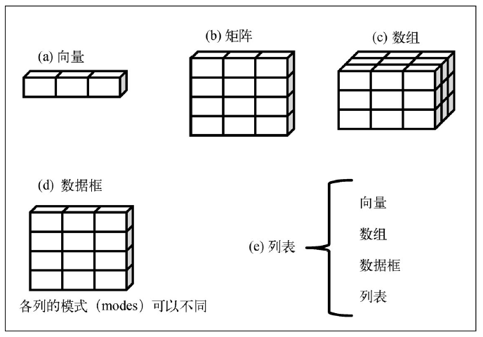

**Do It Yourself**

向量的元素也可以有名字，访问向量的元素也可以用元素的名字作为下标，方法与操作列表相同。作为自学内容。

```r
studentAge <- c(Liu=20, Zhang=21, Chen=19)  #各元素都有名字
studentAge
##   Liu Zhang  Chen
##    20    21    19

studentAge["Zhang"]  #用名字访问元素。得到的是一个元素（还是向量）
## Zhang
##    21

studentAge[["Zhang"]]  #用双重括号访问，所得到的向量不再有名字
## [1] 21

studentAge[c("Chen", "Liu")]  #访问多个元素
## Chen  Liu
##   19   20

names(studentAge)  #获取所有元素的名字
## [1] "Liu"   "Zhang" "Chen"

names(studentAge)[2] <- "Huang"  #为第2个元素重命名
studentAge
##   Liu Huang  Chen
##    20    21    19
```

创建向量最常用的函数是`c()`，另一个常用的函数是`vector()`，该函数可创建一个指定长度的向量，其语法为：

myvector <- vector(mode, length)

其中，参数mode是向量元素的数据类型，可取`"numeric", "logical", "character", "complex"或 "raw"`；参数length指定了向量的长度。`vector()`在创建向量时，会使用每种数据类型的默认值来初始化，例如，numeric向量将用0初始化，logical向量将用FALSE初始化，character将用`""`初始化。

```r
a <- vector("numeric", 10)
a
##  [1] 0 0 0 0 0 0 0 0 0 0

b <- vector("logical", 5)
b
## [1] FALSE FALSE FALSE FALSE FALSE
```

## 衍生数据类型之一：因子(factor)

**因子(factor)**是一种常用的衍生数据类型。在数据分析时，变量有三种类型：

- 名义型。例如：性别，可取“male”和“female”。名义型变量的值没有大小之分；
- 有序型。例如：学历，可取“primary”、“middle”、“high”。有序型变量的值有大小之分，可以进行比较，但是不能进行加减等运算。
- 连续型。例如：身高、年龄，可取连续数值。连续型变量的值有大小之分，并可以进行算术计算。

名义型变量和有序型向量在R中通常转化为**因子**进行处理。例如：

> `c("Male", "Female", "Male", "Male", "Female")`

这个的向量如果直接使用字符串保存，会非常占用磁盘空间，计算时也很缓慢。通常的做法是，用0和1来表示性别，例如0表示“Male”、1表示“Female”，把上面的向量转换为：

> `c(0, 1, 0, 0, 1)`

这实际上就是要把一个向量转换成一个因子。

在R中，将一个向量转换成因子的函数是`factor()`，语法是：

myfactor <- factor(myvector, ordered=bValue, levels=mylevels)

其中，参数`ordered`指定生成的因子是否是有序型因子；参数`levels`指定了生成的因子的值域，`myvector`的元素都必须是`levels`中的值。例如：

```r
gender <-c("Male", "Female", "Female")
new_gender <- factor(gender, ordered=FALSE, levels=c("Male", "Female"))
new_gender
```

```
## [1] Male   Female Female
## Levels: Male Female
```

```r
status <- c("Poor", "Improved","Excellent","Poor")
new_status <- factor(status, ordered=TRUE, levels=c("Poor", "Improved", "Excellent"))
new_status
```

```
## [1] Poor      Improved  Excellent Poor
## Levels: Poor < Improved < Excellent
```

我们可以使用函数`levels()`查看一个因子的水平值，用`nlevels()`计算一个因子的水平值的个数。例如：

```r
gender <-c("Male", "Female", "Female")
new_gender <- factor(gender, ordered=FALSE, levels=c("Male", "Female"))
levels(new_gender)
```

```
## [1] "Male"   "Female"
```

```r
nlevels(new_gender)  #等价于length(levels(new_gender))
```

```
## [1] 2
```

在R内部，因子的值是以整数1、2、3、…来保存的，对于

myfactor <- factor(myvector, ordered=bValue, levles=mylevels)

`mylevels[1]`对应于1，`mylevels[2]`对应于2，依次类推；`myvector`会按照这个规则被转换成整数值保存为因子。例如，

```r
status <- c("Poor", "Improved","Excellent","Poor")
new_status <- factor(status, ordered=TRUE, levles=c("Poor", "Improved", "Excellent"))
```

有1=“Poor”、2=“Improved”、3=“Excellent”，`new_status`的实际值是`c(1, 2, 3, 1)`。

因为整数值比字符串更节省存储空间、更易进行计算（例如进行比较），因此将向量转换成因子后，能显著节省空间，计算更快。

R允许在调用`factor()`时省略参数`levels`，即：

myfactor <- factor(myvector, ordered=bValue)

此时，`factor()`函数会找出`myvector`的取值范围，将各值按字母顺序排序，作为因子水平。例如：

```r
education <- c("high", "middle", "high", "other", "primary")

#下面的语句等价于bad_result <- factor(education, ordered=TRUE, levels=c("high", "middle","other", "primary"))
bad_result <-factor(education, ordered=TRUE)
bad_result
```

```
## [1] high    middle  high    other   primary
## Levels: high < middle < other < primary
```

```r
#自己指定levels，注意levels应当包含所有出现在向量中的值
good_result <- factor(education, ordered=TRUE, levels=c("primary", "middle", "high", "other"))
good_result
```

```
## [1] high    middle  high    other   primary
## Levels: primary < middle < high < other
```

对于有序型变量(即ordered=TRUE的变量)，建议在创建因子时自己手动编码。

因子的使用方法与向量的使用方法相同。例如：

```r
education <- c("high", "middle", "high", "other", "primary")
new_education <- factor(education, ordered=TRUE, levels=c("primary", "middle", "high", "other"))
new_education[2:4]
```

```
## [1] middle high   other
## Levels: primary < middle < high < other
```

```r
new_education[4] <- "middle"   #修改第4个元素的值，将other改为middle
new_education
```

```
## [1] high    middle  high    middle  primary
## Levels: primary < middle < high < other
```

一个因子的`levels`是这个因子的值域，因子的各元素只能在`levels`内取值，不在`levels`中的值会被当作NA处理。例如：

```r
diabetes <-c("Type1","Type2","Type1")
new_diabetes <- factor(diabetes, ordered=FALSE, levels=c("Type1", "Type2"))
new_diabetes
```

```
## [1] Type1 Type2 Type1
## Levels: Type1 Type2
```

```r
new_diabetes[2] <- "Type3"   # "Type3"不在levels范围内，error
new_diabetes
```

```
## [1] Type1 <NA>  Type1
## Levels: Type1 Type2
```

我们可以修改一个因子的`levels`，扩大它的取值范围。例如：

```r
diabetes <-c("Type1","Type2","Type1")
new_diabetes <- factor(diabetes, ordered=FALSE, levels=c("Type1", "Type2"))
levels(new_diabetes) <- c("Type1", "Type2", "Type3")
new_diabetes[2] <- "Type3"
new_diabetes
```

```
## [1] Type1 Type3 Type1
## Levels: Type1 Type2 Type3
```

levels是因子的取值范围，允许levels包括没有出现在因子元素中的值。因为每次调整因子的levels会都造成重新编码计算，比较耗时，因此通常的做法是，在用`factor()`构造因子时，指定一个足够大的levels，避免以后再调整。

```r
diabetes <-c("Type1","Type2","Type1")
new_diabetes <- factor(diabetes, ordered=FALSE, levels=c("Type1", "Type2", "Type3", "Type4"))
new_diabetes
```

```
## [1] Type1 Type2 Type1
## Levels: Type1 Type2 Type3 Type4
```

```r
new_diabetes[1] <- "Type4"
new_diabetes
```

```
## [1] Type4 Type2 Type1
## Levels: Type1 Type2 Type3 Type4
```

在用`data.frame()`创建数据框时，对于所有字符型的列，`data.frame()`会自动调用`factor()`把它们转换成因子再放入数据框。

```r
diabetes <-c("Type1","Type2","Type1","Type1")
status <- c("Poor", "Improved","Excellent","Poor")
mydata <- data.frame(diabetes, status)
mydata
```

```
##   diabetes    status
## 1    Type1      Poor
## 2    Type2  Improved
## 3    Type1 Excellent
## 4    Type1      Poor
```

```r
mydata$diabetes   # diabetes会被自动转换成因子
```

```
## [1] Type1 Type2 Type1 Type1
## Levels: Type1 Type2
```

如果`factor()`的默认行为不能满足要求，就需要自己动手，先把各列转换成因子，再创建数据框。

```r
diabetes <-c("Type1","Type2","Type1","Type1")
status <- c("Poor", "Improved","Excellent","Poor")
status <- factor(status, ordered=TRUE, levels=c("Poor","Improved","Excellent"))
mydata <- data.frame(diabetes, status)
mydata
```

```
##   diabetes    status
## 1    Type1      Poor
## 2    Type2  Improved
## 3    Type1 Excellent
## 4    Type1      Poor
```

因为因子比字符串更为节省存储空间，并且更易进行处理，因此通常是把字符串数据转换成因子后，再放入数据框。

如果不希望`data.frame()`自动把字符串向量转换为因子，可以使用参数`stringsAsFactors=FALSE`。

```r
diabetes <-c("Type1","Type2","Type1","Type1")
status <- c("Poor", "Improved","Excellent","Poor")
mydata <- data.frame(diabetes, status, stringsAsFactors=FALSE)
mydata$status
## [1] "Poor"      "Improved"  "Excellent" "Poor"
```

创建数据框的标准步骤：

1. 创建各数值列；
2. 创建各字符串列。如果有必要，将字符串向量转换为因子；
3. （可选）创建各行的名字向量；
4. 调用data.frame()将各列合并为数据框（使用参数stringsAsFactors=FALSE）。

## 获取数据

进行数据分析，首先需要要数据。数据来源有：

- 手动输入
- 从外部数据源导入到R（自学）

## 手动输入数据

手动输入一个数据框的数据分为两步：

1. 创建一个空的数据框，这个空的数据框用于指定各列的数据类型；
2. 调用函数`edit()`输入数据。

函数`edit()`会打开一个编辑器窗口，可以在此编辑数据、修改列的名字、增加列。例如：

```r
#首先创建一个空的数据框，有3列，各列的名字分别是age, gender, weight
newdata <- data.frame(age=numeric(0), gender=character(0), weight=numeric(0))

#打开编辑器输入数据，并把结果保存下来
newdata <- edit(newdata)
```

对已经存在的数据框，也可以调用`edit()`进行编辑。

## Advance Topic: []与[[]]的区别

R中实际上只有两种组合数据类型：向量(vector)和列表(list)。参见Chapter20。

标量、矩阵、数组都是特殊的向量(vector)。向量的特点是各元素都是同一类型（数字、字符串、逻辑型等）。访问vector的元素是使用运算符`[]`。

```r
a <- c(1:10);  is.vector(a);  class(a)
## [1] TRUE
## [1] "integer"

attr(a, "dim") <- c(2, 5)    #只需改变vector的dim属性，就可以将一个vector转换成matrix
a
##      [,1] [,2] [,3] [,4] [,5]
## [1,]    1    3    5    7    9
## [2,]    2    4    6    8   10

is.vector(a); is.matrix(a);  class(a) #确认a不再是一个vector, a已经是一个matrix
## [1] FALSE
## [1] TRUE
## [1] "matrix"

b <- c(2, 5, 7); is.vector(b)
## [1] TRUE
is.vector(b[2])   # b[2]是一个标量值。标量是一种特殊的向量
## [1] TRUE
```

列表(list)是非常重要的“容器”，我们可以将各种不同类型的数据放入一个列表。列表的内部结构与向量(vector)有本质不同，在调用函数`list()`创建列表时，该函数会先将各元素都转换成一个列表，然后再将这些列表组合成最终的列表，也就是说，**列表的每个元素仍然是列表**。用`[]`可以访问到列表的元素（仍是一个列表），用`[[]]`则可以访问到列表各元素内的值。

```r
myname <- "Liu"
mysalary <- c(1:10)
mylist <- list(myname, mysalary)

class(mylist)
## [1] "list"

class(mylist[2])  #mylist[2]仍然是一个list
## [1] "list"

class(mylist[[2]])  #mylist[[2]]是一个向量
## [1] "integer"
```

请比较list和vector的输出形式：

```r
mylist[2]
## [[1]]
##  [1]  1  2  3  4  5  6  7  8  9 10

mylist[[2]]
##  [1]  1  2  3  4  5  6  7  8  9 10
```

DIY：设`x <- list(list(1, 2), c(5,6))`，要求提取出数字1和5，并且要求结果是一个vector。

```r
x <- list(list(1, 2), c(5,6))
c( x[[1]][[1]], x[[2]][1] )  #请注意访问list与vector的区别
```

```
## [1] 1 5
```

数据框是特殊的列表。对于数据框，有类似的结果。

```r
class(mtcars)
## [1] "data.frame"

class(mtcars[1])  #mtcars[1]仍是一个data.frame
## [1] "data.frame"

class(mtcars[[1]])  #mtcars[[1]]是一个vector
## [1] "numeric"
```

比较`mtcars[1]`和`mtcars[[1]]`的值

```r
mtcars[1]
```

```
##                      mpg
## Mazda RX4           21.0
## Mazda RX4 Wag       21.0
## Datsun 710          22.8
## Hornet 4 Drive      21.4
## Hornet Sportabout   18.7
## Valiant             18.1
## Duster 360          14.3
## Merc 240D           24.4
## Merc 230            22.8
## Merc 280            19.2
## Merc 280C           17.8
## Merc 450SE          16.4
## Merc 450SL          17.3
## Merc 450SLC         15.2
## Cadillac Fleetwood  10.4
## Lincoln Continental 10.4
## Chrysler Imperial   14.7
## Fiat 128            32.4
## Honda Civic         30.4
## Toyota Corolla      33.9
## Toyota Corona       21.5
## Dodge Challenger    15.5
## AMC Javelin         15.2
## Camaro Z28          13.3
## Pontiac Firebird    19.2
## Fiat X1-9           27.3
## Porsche 914-2       26.0
## Lotus Europa        30.4
## Ford Pantera L      15.8
## Ferrari Dino        19.7
## Maserati Bora       15.0
## Volvo 142E          21.4
```

```r
mtcars[[1]]
```

```
##  [1] 21.0 21.0 22.8 21.4 18.7 18.1 14.3 24.4 22.8 19.2 17.8 16.4 17.3 15.2
## [15] 10.4 10.4 14.7 32.4 30.4 33.9 21.5 15.5 15.2 13.3 19.2 27.3 26.0 30.4
## [29] 15.8 19.7 15.0 21.4
```

运算符`$`的功能与`[[]]`相同。

```r
class(mtcars$mpg)
## [1] "numeric"

mtcars$mpg
##  [1] 21.0 21.0 22.8 21.4 18.7 18.1 14.3 24.4 22.8 19.2 17.8 16.4 17.3 15.2
## [15] 10.4 10.4 14.7 32.4 30.4 33.9 21.5 15.5 15.2 13.3 19.2 27.3 26.0 30.4
## [29] 15.8 19.7 15.0 21.4
```